# lez03a: Statistica descrittiva

## Il database "iris"

Uno dei dataset più utilizzati per la statistica è senza dubbio `iris`: la collezione di 150 misure di larghezza e lunghezza di petali e sepali di iris appartenenti a tre diverse specie:

```r
iris
```

| Sepal.Length | Sepal.Width | Petal.Length | Petal.Width | Species |
| --- | --- | --- | --- | --- |
| 5.1 | 3.5 | 1.4 | 0.2 | setosa |
| 4.9 | 3.0 | 1.4 | 0.2 | setosa |
| 4.7 | 3.2 | 1.3 | 0.2 | setosa |
| 4.6 | 3.1 | 1.5 | 0.2 | setosa |
| 5.0 | 3.6 | 1.4 | 0.2 | setosa |
| 5.4 | 3.9 | 1.7 | 0.4 | setosa |
| 4.6 | 3.4 | 1.4 | 0.3 | setosa |
| 5.0 | 3.4 | 1.5 | 0.2 | setosa |
| 4.4 | 2.9 | 1.4 | 0.2 | setosa |
| 4.9 | 3.1 | 1.5 | 0.1 | setosa |

[output cut: 140 more lines]

la lunghezza dei petali può essere utilizzata come esempio di una tipica variabile continua misurata in campo:

è abbastanza chiaro che guardare i dati grezzi non ci porta da nessuna parte…

```r
iris$Petal.Length
```

```
##   [1] 1.4 1.4 1.3 1.5 1.4 1.7 1.4 1.5 1.4 1.5 1.5 1.6 1.4 1.1 1.2 1.5 1.3
##  [18] 1.4 1.7 1.5 1.7 1.5 1.0 1.7 1.9 1.6 1.6 1.5 1.4 1.6 1.6 1.5 1.5 1.4
##  [35] 1.5 1.2 1.3 1.4 1.3 1.5 1.3 1.3 1.3 1.6 1.9 1.4 1.6 1.4 1.5 1.4 4.7
##  [52] 4.5 4.9 4.0 4.6 4.5 4.7 3.3 4.6 3.9 3.5 4.2 4.0 4.7 3.6 4.4 4.5 4.1
##  [69] 4.5 3.9 4.8 4.0 4.9 4.7 4.3 4.4 4.8 5.0 4.5 3.5 3.8 3.7 3.9 5.1 4.5
##  [86] 4.5 4.7 4.4 4.1 4.0 4.4 4.6 4.0 3.3 4.2 4.2 4.2 4.3 3.0 4.1 6.0 5.1
## [103] 5.9 5.6 5.8 6.6 4.5 6.3 5.8 6.1 5.1 5.3 5.5 5.0 5.1 5.3 5.5 6.7 6.9
## [120] 5.0 5.7 4.9 6.7 4.9 5.7 6.0 4.8 4.9 5.6 5.8 6.1 6.4 5.6 5.1 5.6 6.1
## [137] 5.6 5.5 4.8 5.4 5.6 5.1 5.1 5.9 5.7 5.2 5.0 5.2 5.4 5.1
```

## `summary()`

*da non confondere con la funzione `summarise()` che vedremo tra poco*

```r
summary(iris$Petal.Length)
```

```
##    Min. 1st Qu.  Median    Mean 3rd Qu.    Max.
##   1.000   1.600   4.350   3.758   5.100   6.900
```

- `Min.`: il valore minimo
- `1st Qu`.: il primo **quartile** ossia il valore entro cui stanno il 25% dei dati
- `Median`: la mediana, *che è anche il secondo quartile*
- `Mean`: la **media aritmetica** dei valori **(non finisce qui)**
- `3rd Qu.`: il terzo **quartile**
- `Max.`: il valore massimo

è uno strumento eccezionale per verificare che non ci siano errori nell'acquisizione dei dati:

```r
summary(iris)
```

```
##   Sepal.Length    Sepal.Width     Petal.Length    Petal.Width
##  Min.   :4.300   Min.   :2.000   Min.   :1.000   Min.   :0.100
##  1st Qu.:5.100   1st Qu.:2.800   1st Qu.:1.600   1st Qu.:0.300
##  Median :5.800   Median :3.000   Median :4.350   Median :1.300
##  Mean   :5.843   Mean   :3.057   Mean   :3.758   Mean   :1.199
##  3rd Qu.:6.400   3rd Qu.:3.300   3rd Qu.:5.100   3rd Qu.:1.800
##  Max.   :7.900   Max.   :4.400   Max.   :6.900   Max.   :2.500
##        Species
##  setosa    :50
##  versicolor:50
##  virginica :50
##
##
##
```

da notare che fornisce automaticamente anche le abbondanze dei dati che vengono immagazzinati come `factor`, quindi **variabili qualitative** in questo caso *non ordinate*

```r
summary(iris$Species)
```

```
##     setosa versicolor  virginica
##         50         50         50
```

## Un grafico

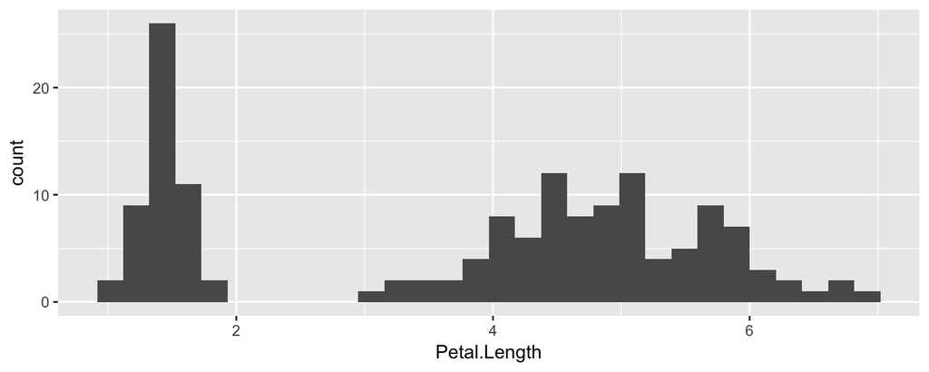

```r
ggplot() +
    geom_histogram(data = iris,
                   aes(x = Petal.Length))
```

`?geom_histogram` ci fornisce qualche indicazione in più, anche se non è chiarissimo nella differenza fra il parametro `bins` e `binwidth`.

- `bins` imposta il numero di barre
- `binwidth` imposta la largezza delle barre stesse

in questo caso i valori sono arrotondati al millimetro,  
`binwidth = 0.1`:

## A proposito di ISTOGRAMMI

è molto pericoloso utilizzare un numero di classi diverso da quello originale.  
In termini tecnici, se la variabile non è *veramente continua* ma è già *binned*, cioè già riassunta in classi (che siano vere classi, come le classi di diametro, o che sia a causa di un arrotondamento) è fortemente sconsigliato il *rebinning*, cioè un secondo raggruppamento in classi più ampie.

**Questa azione può generare più di un artefatto nei dati!**

## `binwidth = 0.1`

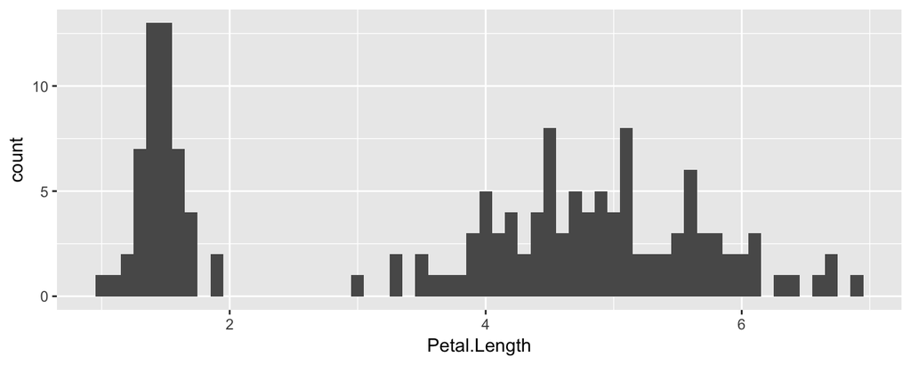

```r
ggplot() +
    geom_histogram(data = iris,
                   aes(x = Petal.Length),
                   binwidth = 0.1)
```

## Un grafico decente

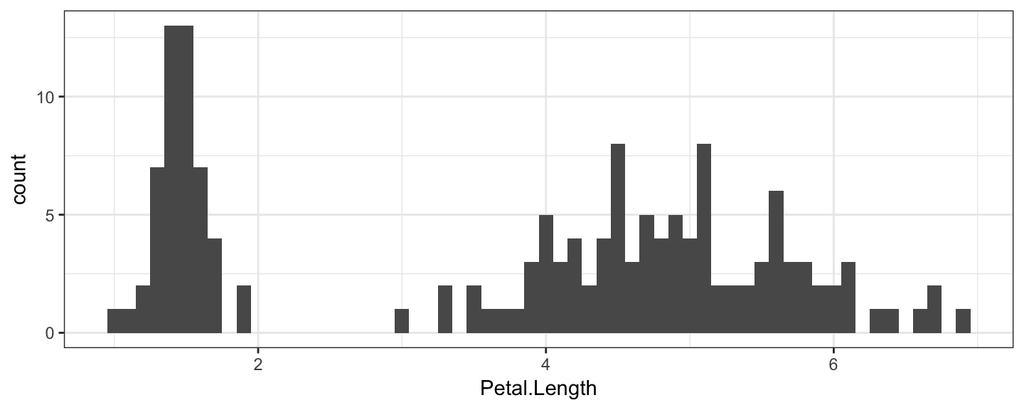

```r
ggplot() +
    geom_histogram(data = iris,
                   aes(x = Petal.Length),
                   binwidth = 0.1) +
    theme_bw()
```

## Un bel grafico

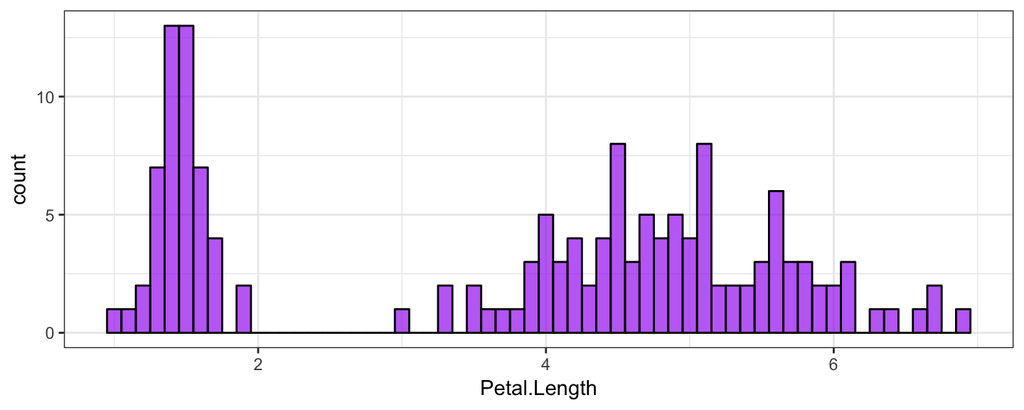

```r
ggplot() +
    geom_histogram(data = iris,
                   aes(x = Petal.Length),
                   binwidth = 0.1,
                   fill = "purple", color = "black",
                   alpha = 2/3) +
    theme_bw()
```

## Un bel grafico corretto

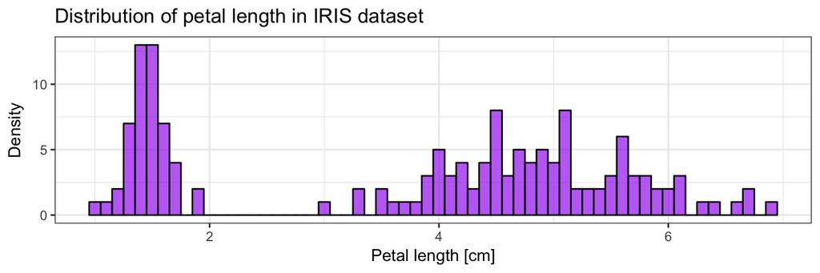

```r
ggplot() +
    geom_histogram(data = iris,
                   aes(x = Petal.Length),
                   binwidth = 0.1,
                   fill = "purple", color = "black", alpha = 2/3) +
    labs(title = "Distribution of petal length in IRIS dataset",
         x = "Petal length [cm]",
         y = "Density") +
    theme_bw()
```

## Un po' di magia

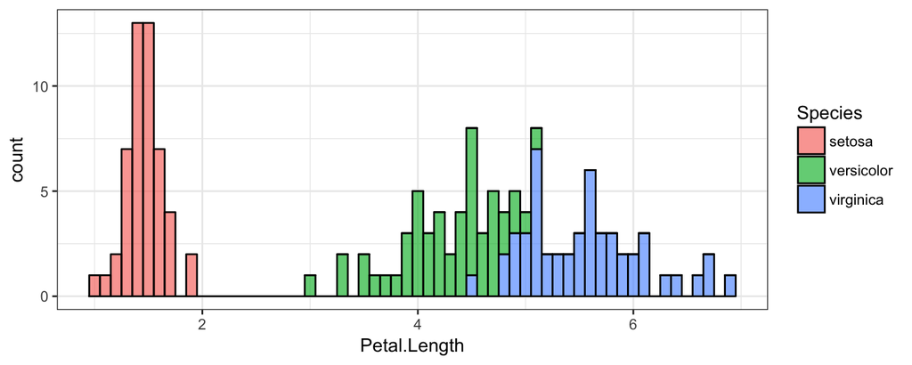

```r
ggplot() +
    geom_histogram(data = iris, aes(x = Petal.Length, fill = Species),
                   alpha = 2/3, binwidth = 0.1, color = "black") +
    theme_bw()
```

## `geom_density()`

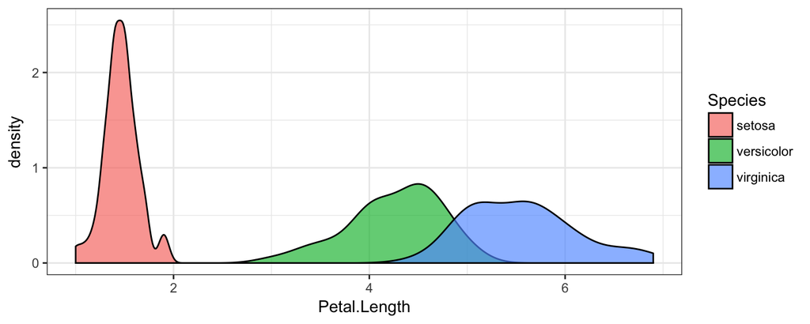

```r
ggplot() +
    geom_density(data = iris, aes(x = Petal.Length, fill = Species),
                 alpha = 2/3, color = "black") +
    theme_bw()
```

O con le classiche barre affiancate (`position = "dodge"`)

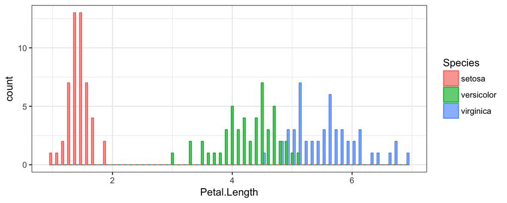

```r
ggplot() +
    geom_histogram(data = iris,
                 aes(x = Petal.Length, fill = Species, color = Species),
                 alpha = 2/3, binwidth = 0.1,
                 position = "dodge") + # <<<---
    theme_bw()
```

## La media

## La *media* non vuol dire un accidente di niente:

- Media aritmetica
- Media quadratica
- Media geometrica
- Media armonica
- Mediana
- Moda

Questi sono tutti **indicatori di tendenza centrale**

## Media aritmetica

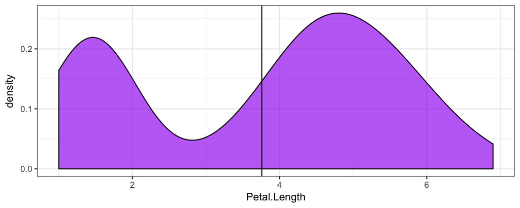

```r
ggplot() +
    geom_density(data = iris,
                 aes(x = Petal.Length),
                 fill = "purple", alpha = 2/3) +
    geom_vline(xintercept = mean(iris$Petal.Length)) + # <<<---
    theme_bw()
```

## Mediana

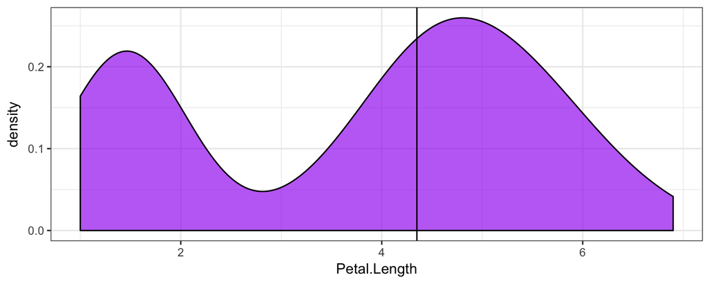

```r
ggplot() +
    geom_density(data = iris,
                 aes(x = Petal.Length),
                 fill = "purple", alpha = 2/3) +
    geom_vline(xintercept = median(iris$Petal.Length)) + # <<<---
    theme_bw()
```

## Moda

In generale la moda fa schifo a tutti.

## Un approccio serio al problema della media

### **La media di Chisini**

la media dipende dalle variabili e **dalla funzione a cui sono destinate**.

In soldoni: il valore medio è quel valore che mi permetterebbe di ottenere lo stesso risultato se tutti i valori fossero uguali:

Per una definizione rigorosa:  
Chisini, O. "Sul concetto di media." Periodico di Matematiche 4, 106-116, 1929.

Se due alberi hanno due altezze diverse il risultato che io sto cercando di tenere fisso è la somma delle altezze, quindi:

\[h1 + h2 = H\] \[m + m = H\] \[2m = H\] \[2m = h1+h2\] \[m = \frac{h1+h2}{2}\] **MEDIA ARITMETICA**

## Il *diametro medio* è il diametro dell'albero di area basimetrica media.

La scelta della media da calcolare non è banale, spesso non c'è un'unica risposta giusta, un buon punto da cui iniziare può essere questa pagina di CrossValidated: [Which "mean" to use and when](https://stats.stackexchange.com/questions/23117/which-mean-to-use-and-when).

La media, come *indicatore di tendenza centrale* spesso è sopravvalutato, in molti casi la mediana (insieme ai quartili e percentili) è più *stabile*, nel senso che è meno soggetta alla presenza di valori estremi che spesso sono generati da errori, o comunque sono poco precisi rispetto al loro peso.

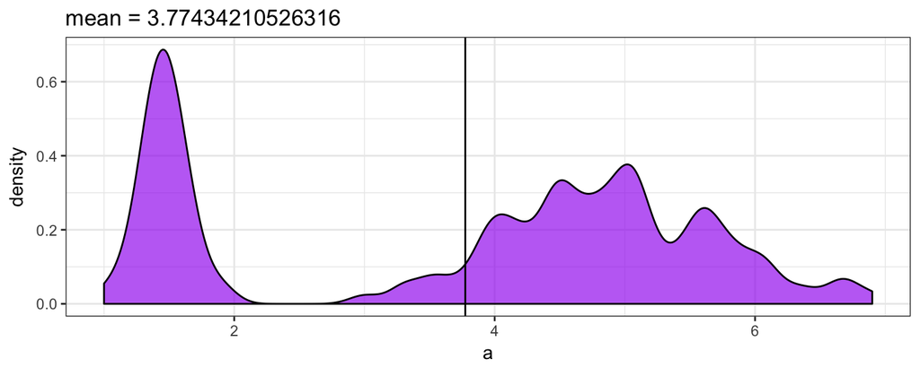

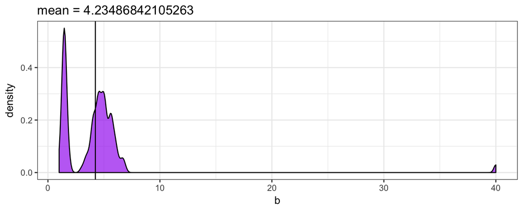

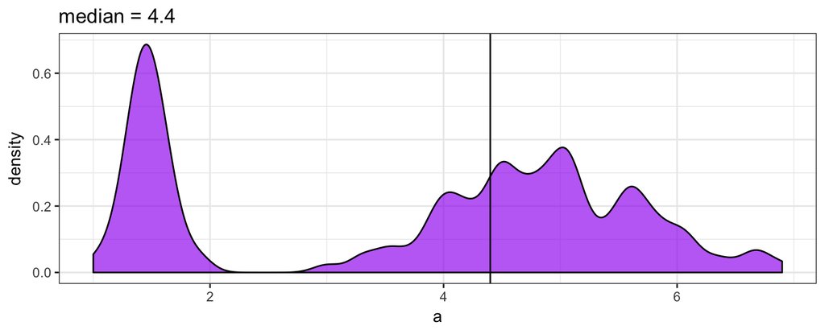

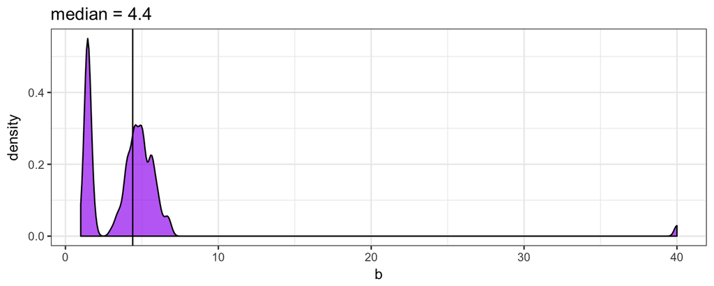

## QUANTILI (quartili e percentili)

In generale si intende come **percentili**, i valori per cui una determinata percentuale della popolazione ha un valore minore:

- 1° percentile : 1% dei valori (più bassi)
- 25° percentile = 1° quartile : 25% dei valori
- 50° percentile = 2° quartile = mediana : 50% dei valori

La funzione `quantile()` fornisce di default i quartili

```r
quantile(iris$Petal.Length)
```

```
##   0%  25%  50%  75% 100%
## 1.00 1.60 4.35 5.10 6.90
```

se vogliamo il 5° percentile (5% = 0.05) basta indicarlo nell'argomento `probs`

```r
quantile(iris$Petal.Length, probs = 0.05)
```

```
##  5%
## 1.3
```

```r
quantile(iris$Petal.Length, probs = 0:10/10)
```

```
##   0%  10%  20%  30%  40%  50%  60%  70%  80%  90% 100%
## 1.00 1.40 1.50 1.70 3.90 4.35 4.64 5.00 5.32 5.80 6.90
```

I quartili, come qualsiasi quantile posso essere facilmente graficati:

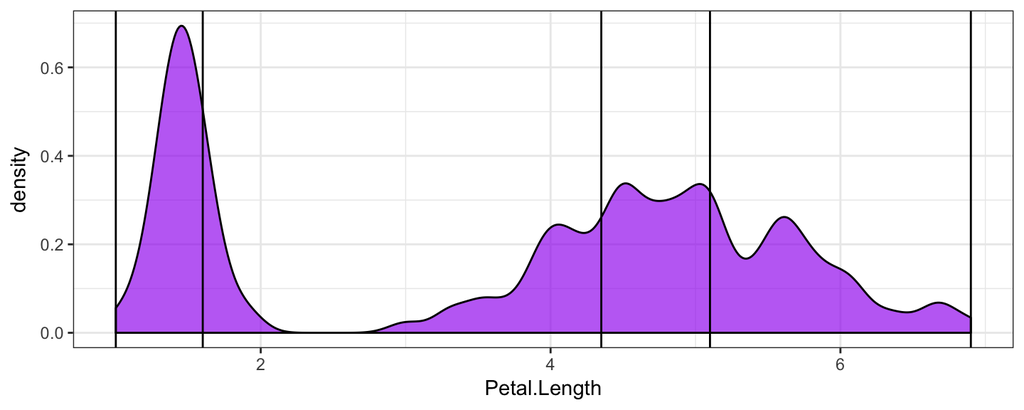

```r
ggplot() +
    geom_density(data = iris,
                 aes(x = Petal.Length),
                 fill = "purple", alpha = 2/3, adjust = 1/5) +
    geom_vline(xintercept = quantile(iris$Petal.Length)) + # <<<---
    theme_bw()
```

### Graficare i quantili

se voglio sfruttare ggplot, devo fornire i dati in un `data_frame`:  
in una colonna le etichette che andranno nella legenda  
in un'altra i valori a cui andranno le linee

vediamo com'è fatto l'oggetto restituito da `quantile()`

```r
quant_object <- quantile(iris$Petal.Length)

str(quant_object)
```

```
##  Named num [1:5] 1 1.6 4.35 5.1 6.9
##  - attr(*, "names")= chr [1:5] "0%" "25%" "50%" "75%" ...
```

```r
names(quant_object)
```

```
## [1] "0%"   "25%"  "50%"  "75%"  "100%"
```

Creare il `dataframe`

```r
quant_iris <- data_frame(quantile = names(quant_object),
                         position = quant_object)

quant_iris
```

| quantile | position |
| --- | --- |
| 0% | 1.00 |
| 25% | 1.60 |
| 50% | 4.35 |
| 75% | 5.10 |
| 100% | 6.90 |

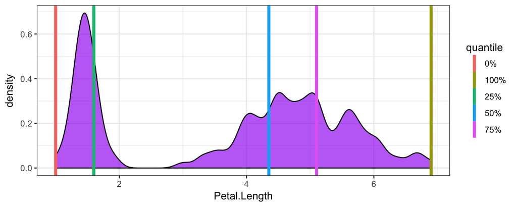

```r
ggplot() +
    geom_density(data = iris,
                 aes(x = Petal.Length),
                 fill = "purple", alpha = 2/3, adjust = 1/5) +
    geom_vline(data = quant_iris,
               aes(color = quantile, xintercept = position), # <<<---
               size = 1.5) +
    theme_bw()
```

Creare il `dataframe`, **imponendo l'ordine dei nomi**

```r
quant_iris <- data_frame(quantile = as_factor(names(quant_object),
                                              ordered = TRUE),
                         position = quant_object)

quant_iris
```

| quantile | position |
| --- | --- |
| 0% | 1.00 |
| 25% | 1.60 |
| 50% | 4.35 |
| 75% | 5.10 |
| 100% | 6.90 |

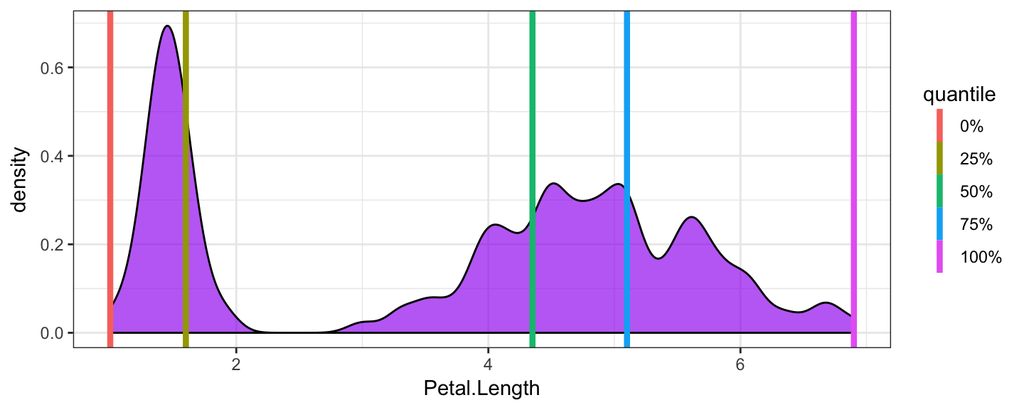

```r
ggplot() +
    geom_density(data = iris,
                 aes(x = Petal.Length),
                 fill = "purple", alpha = 2/3, adjust = 1/5) +
    geom_vline(data = quant_iris,
               aes(color = quantile, xintercept = position), # <<<---
               size = 1.5) +
    theme_bw()
```